# Case Study 2: Reuters – Multi-class Classification of News Articles

# Initial model

Slides: - Discuss what the loss function means

First, let’s randomize our data to make sure we don’t have any ordering problems when using `validation_split`:

```r
# I use seed = 123 often but it has not significant meaning
set.seed(123)
index <- sample(1:nrow(x_train))
x_train <- x_train[index,]
y_train <- y_train[index,]
```

Since we are performing multi-class classification, our output activation function will be the *softmax activation function* and our loss function will be *categorical crossentropy*.

```r
network <- keras_model_sequential() %>%
  layer_dense(units = 64, activation = "relu", input_shape = n_features) %>%
  layer_dense(units = 64, activation = "relu") %>%
  layer_dense(units = 46, activation = "softmax") %>%
  compile(
    optimizer = "rmsprop",
    loss = "categorical_crossentropy",
    metrics = c("accuracy")
  )

history <- network %>% fit(
  x_train,
  y_train,
  epochs = 20,
  batch_size = 512,
  validation_split = 0.2
)
```

```
Train on 7185 samples, validate on 1797 samples
```

Our model minimizes the loss score at the following epoch:

```r
as.data.frame(history) %>%
  filter(data == 'validation') %>%
  spread(metric, value) %>%
  filter(loss == min(loss))
```

| epoch | data | loss | acc |
| --- | --- | --- | --- |
| 10 | validation | 0.9217593 | 0.7929883 |

# A different way to handle multi-class labels & loss

slides: - categorical crossentropy vs. sparse categorical crossentropy - discuss what this loss actually looks like

First, we need to re-order our labels to align with the randomized training data:

```r
# first we need to re-order our labels to align with the randomized training
# data
train_labels <- train_labels[index]
str(train_labels)
```

```
 int [1:8982] 3 2 3 20 16 13 14 4 4 3 ...
```

We will get nearly identical results; the only difference should come from natural variance in our loss function due to randomness with our initial weights.

```r
as.data.frame(history) %>%
  filter(data == 'validation') %>%
  spread(metric, value) %>%
  filter(loss == min(loss))
```

| epoch | data | loss | acc |
| --- | --- | --- | --- |
| 10 | validation | 0.9173964 | 0.8007791 |

# Regularizing with layers and nodes

slides: - discuss large network vs smaller network - best practices - # layers - # nodes - funnel vs. flat shape

Spend the next 5 minutes increasing and decreasing the number of nodes and layers and assess how they impact performance:

## Variant 1: Larger or smaller layers?

To do this, we’ll define a function `dl_model` that allows us to define and compile our DL network with the specified number of neurons based on $2^n$. This function returns a data frame with the training and validation loss and accuracy for each epoch and number of neurons:

```r
dl_model <- function(powerto = 6) {

  network <- keras_model_sequential() %>%
    layer_dense(units = 2^powerto, activation = "relu", input_shape = n_features) %>%
    layer_dense(units = 2^powerto, activation = "relu") %>%
    layer_dense(units = 46, activation = "softmax") %>%
    compile(
      optimizer = "rmsprop",
      loss = "categorical_crossentropy",
      metrics = c("accuracy")
      )

  history <- network %>%
    fit(
      x_train,
      y_train,
      epochs = 20,
      batch_size = 512,
      validation_split = 0.2,
      verbose = FALSE
    )

  output <- as.data.frame(history) %>%
    mutate(neurons = 2^powerto)

  return(output)
  }
```

Let’s also define a helper function that simply pulls out the minimum loss score from the above output (this is not necessary, just informational):

```r
get_min_loss <- function(output) {
  output %>%
    filter(data == "validation", metric == "loss") %>%
    summarize(min_loss = min(value)) %>%
    pull()
}
```

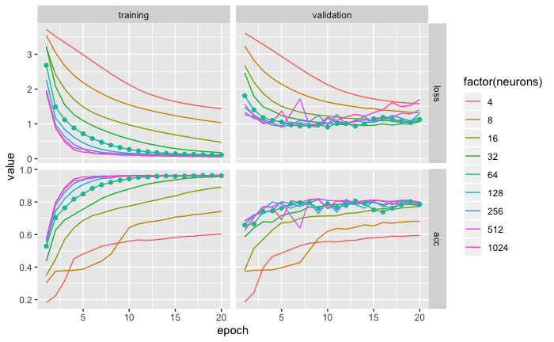

```r
ggplot(results, aes(epoch, value, color = factor(neurons))) +
  geom_line() +
  geom_point(data = filter(results, neurons == 64), show.legend = FALSE) +
  facet_grid(metric ~ data, scales = 'free_y')
```

## Variant 2: More or less layers?

We can perform a similar approach to assess the impact that the number of layers has on model performance. The following modifies our `dl_model` so that we can dynamically alter the number of layers and neurons.

```r
dl_model <- function(nlayers = 2, powerto = 6) {

  # Create a model with a single hidden input layer
  network <- keras_model_sequential() %>%
    layer_dense(units = 2^powerto, activation = "relu", input_shape = n_features)

  # Add additional hidden layers based on input
  if (nlayers > 1) {
    for (i in seq_along(nlayers - 1)) {
      network %>% layer_dense(units = 2^powerto, activation = "relu")
    }
  }

  # Add final output layer
  network %>% layer_dense(units = 46, activation = "softmax")


  # Add compile step
  network %>% compile(
      optimizer = "rmsprop",
      loss = "categorical_crossentropy",
      metrics = c("accuracy")
      )

  # Train model
  history <- network %>%
    fit(
      x_train,
      y_train,
      epochs = 20,
      batch_size = 512,
      validation_split = 0.2,
      verbose = FALSE
    )

  # Create formated output for downstream plotting & analysis
  output <- as.data.frame(history) %>%
    mutate(nlayers = nlayers, neurons = 2^powerto)

  return(output)
  }
```

Now we can iterate over a range of layers and neurons in each layer to assess the impact to performance. For time, we’ll use hidden layers with 64 nodes and just assess the impact of adding more layers:

```r
# so that we can store results
results <- data.frame()
nlayers <- 1:8

for (i in nlayers) {
  cat("Running model with", i, "hidden layer and 64 neurons per layer: ")
  m <- dl_model(nlayers = i, powerto = 6)
  results <- rbind(results, m)
  loss <- get_min_loss(m)
  cat(loss, "\n", append = TRUE)
}
```

```
Running model with 1 hidden layer and 64 neurons per layer: 0.8447345
Running model with 2 hidden layer and 64 neurons per layer: 0.9603361
Running model with 3 hidden layer and 64 neurons per layer: 0.944901
Running model with 4 hidden layer and 64 neurons per layer: 0.9181727
Running model with 5 hidden layer and 64 neurons per layer: 0.9291525
Running model with 6 hidden layer and 64 neurons per layer: 0.940812
Running model with 7 hidden layer and 64 neurons per layer: 0.9166849
Running model with 8 hidden layer and 64 neurons per layer: 0.9555994
```

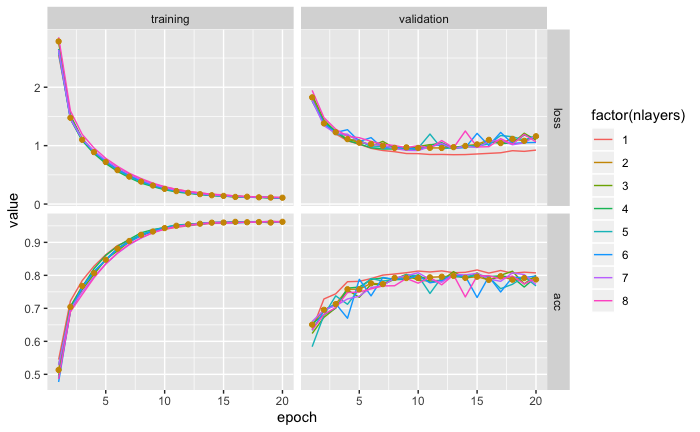

```r
ggplot(results, aes(epoch, value, color = factor(nlayers))) +
  geom_line() +
  geom_point(data = filter(results, nlayers == 2), show.legend = FALSE) +
  facet_grid(metric ~ data, scales = 'free_y')
```

# Evaluate

Now let’s snag our best parameters, train our final model, and evaluate it on our test data:

```r
# Get best model parameters
best_mod <- results %>%
  filter(data == 'validation', metric == 'loss') %>%
  top_n(-1, wt = value)

best_nlayers <- best_mod$nlayers
best_epoch <- best_mod$epoch

# Create a model with a single hidden input layer
final_model <- keras_model_sequential() %>%
  layer_dense(units = 64, activation = "relu", input_shape = n_features)

# Add additional hidden layers based on optimal # of layers (`best_nlayers`)
if (best_nlayers > 1) {
  for (i in seq_along(best_nlayers - 1)) {
    final_model %>% layer_dense(units = 64, activation = "relu")
  }
}

# Add final output layer
final_model %>% layer_dense(units = 46, activation = "softmax")


# Add compile step
final_model %>% compile(
    optimizer = "rmsprop",
    loss = "categorical_crossentropy",
    metrics = c("accuracy")
    )

# Train model based on optimal number of epochs (`best_epoch`)
final_model %>%
  fit(
    x_train,
    y_train,
    epochs = best_epoch,
    batch_size = 512,
    verbose = FALSE
  )

# Evaluate on test data
final_model %>% evaluate(x_test, y_test)
```

```
$loss
[1] 0.9019398

$acc
[1] 0.8000891
```